# Project 2: Data Mining, Classification, Prediction

### Dimensionality Reduction with PCA

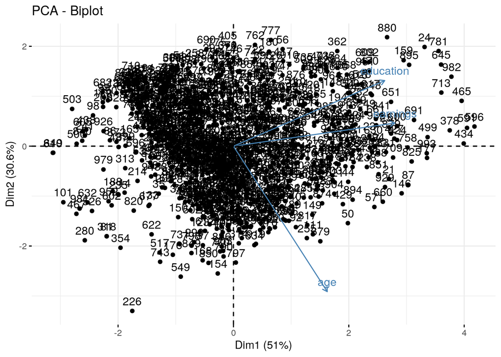

```r
# PCA code here
library(factoextra)
numeric1 <- sample1 %>% select(earnings, age, education)
CPSS_pca <- princomp(numeric1, cor = T)

eigval <- CPSS_pca$sdev^2  #square to convert SDs to eigenvalues
varprop = round(eigval/sum(eigval), 2)  #proportion of var explained by each PC.

fviz_pca_biplot(CPSS_pca)
```

```r
round(cumsum(eigval)/sum(eigval), 2)
```

```
## Comp.1 Comp.2 Comp.3
##   0.51   0.82   1.00
```

```r
summary(CPSS_pca, loadings = T)
```

```
## Importance of components:
##                           Comp.1    Comp.2    Comp.3
## Standard deviation     1.2366147 0.9587980 0.7426240
## Proportion of Variance 0.5097386 0.3064312 0.1838301
## Cumulative Proportion  0.5097386 0.8161699 1.0000000
##
## Loadings:
##           Comp.1 Comp.2 Comp.3
## earnings   0.672  0.143  0.727
## age        0.391 -0.902 -0.183
## education  0.630  0.407 -0.662
```

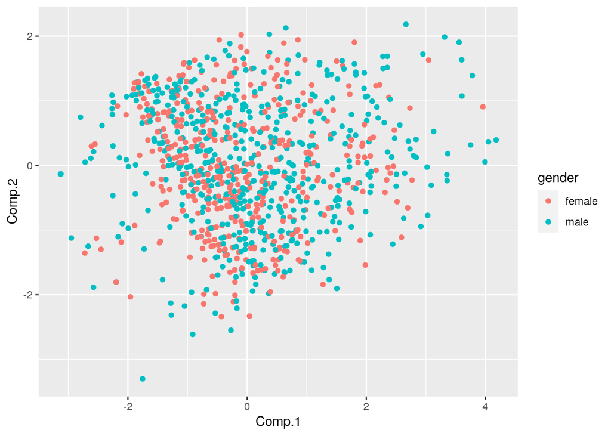

```r
CPSS_pcadf <- CPSS_pca$scores %>% as.data.frame() %>% mutate(gender = sample1$gender)
# CPSS_pca_df %>% bind_cols(Genders = )
CPSS_pcadf %>% ggplot(aes(Comp.1, Comp.2, color = gender)) +
    geom_point()
```

- Looking at the PCA analysis, we will hit 82% of the total variance on 2 components.In this scenario, Principal Component 1 shows that if you have a high principal component 1, it tends to have an increase in all variables with the most significant increase in earnings and education. Vice Versa, if you have a low principal component, it tends to have a low score for earning, age, and education as well. While in component 2, if you score high on y axis, you tend to have more education and earnings with incremental less than component 1, but also be younger in the population. Lastly, a high PC3 values shows an increase in earning, decrease in age, and decrease in education. Another fun fact is looking at the component comparison graph, it seems that male dominated in both high end Comp1 and Comp 2 to the top right side of the corner.

### Linear Classifier

```r
# linear classifier code here

sample2 <- sample1 %>% select(-region, -cluster)

logistic_fit <- glm(gender == "male" ~ ., data = sample2, family = "binomial")
prob_reg <- predict(logistic_fit, type = "response")
class_diag(prob_reg, sample2$gender, positive = "male")
```

```
##          acc   sens   spec    ppv     f1   ba    auc
## Metrics 0.62 0.7065 0.5134 0.6414 0.6724 0.61 0.6521
```

```r
# cross-validation of linear classifier here
set.seed(222)
k = 10

data <- sample_frac(sample2)  #randomly order rows
folds <- rep(1:k, length.out = nrow(data))  #create folds
diags <- NULL

i = 1
for (i in 1:k) {
    # create training and test sets
    train <- data[folds != i, ]
    test <- data[folds == i, ]
    truth <- test$gender

    # train model fit <- glm(Legendary~ -name,., data = train,
    # family = 'binomial')
    fit <- glm(gender ~ ., data = train, family = "binomial")

    # test model
    probs <- predict(fit, newdata = test, type = "response")

    # get performance metrics for each fold
    diags <- rbind(diags, class_diag(probs, truth, positive = "male"))
}

# average performance metrics across all folds
summarize_all(diags, mean)
```

```
##     acc    sens    spec     ppv      f1      ba     auc
## 1 0.613 0.71416 0.49663 0.63385 0.66781 0.60542 0.64905
```

- In the linear classification method, I created a new value named sample2 as variables that only contain numeric information. The AUC is performing at a Poor level for classifying genders between female and male. Which make sense since it will be bad if the classier is able to classify genders based off earning, education, and age alone. But looking at the cross-validation portion, this specific method showed just a tiny bit less auc then out of sample porportion which means overfitting is not an issue

### Non-Parametric Classifier

```r
library(caret)
knn_fit <- knn3(gender == "male" ~ ., data = sample2)

y_hat_knn <- predict(knn_fit, sample2)[, 2]

class_diag(y_hat_knn, sample2$gender, positive = "male")
```

```
##          acc   sens   spec    ppv     f1     ba    auc
## Metrics 0.72 0.7518 0.6808 0.7437 0.7477 0.7163 0.7944
```

```r
# cross-validation of np classifier here
set.seed(222)
k = 10

data <- sample_frac(sample2)  #randomly order rows
folds <- rep(1:k, length.out = nrow(data))  #create folds
diags <- NULL

i = 1
for (i in 1:k) {
    # create training and test sets
    train <- data[folds != i, ]
    test <- data[folds == i, ]
    truth <- test$gender

    # train model
    fit_knn <- knn3(gender ~ ., data = train)

    # test model
    probs_knn <- predict(fit_knn, newdata = test)[, 2]

    # get performance metrics for each fold
    diags <- rbind(diags, class_diag(probs_knn, truth, positive = "male"))
}

# average performance metrics across all folds
summarize_all(diags, mean)
```

```
##    acc   sens    spec     ppv      f1      ba     auc
## 1 0.57 0.6011 0.53542 0.61249 0.60282 0.56827 0.58961
```

### Regression/Numeric Prediction

```r
sample3 <- sample2 %>% select(-gender)
Numeric_fit <- lm(earnings ~ ., data = sample3)
yhat <- predict(Numeric_fit)

mean((sample3$earnings - yhat)^2)
```

```
## [1] 78.98079
```

```r
# cross-validation of regression model here
set.seed(1234)
k = 10  #choose number of folds
data <- sample3[sample(nrow(sample3)), ]  #randomly order rows
folds <- cut(seq(1:nrow(sample3)), breaks = k, labels = F)  #create folds

diags <- NULL
for (i in 1:k) {
    train <- data[folds != i, ]
    test <- data[folds == i, ]
    ## Fit linear regression model to training set
    fit <- lm(earnings ~ ., data = train)
    ## Get predictions/y-hats on test set (fold i)
    yhat <- predict(fit, newdata = test)
    ## Compute prediction error (MSE) for fold i
    diags <- mean((test$earnings - yhat)^2)
}
mean(diags)
```

```
## [1] 79.24075
```

### Python

```r
library(reticulate)
use_python("/usr/bin/python3")
plot <- import("matplotlib")
plot$use("Agg", force = TRUE)
```

```python
# python code here
sample_earnings = r.sample1['earnings']

max_earnings = str(round(sample_earnings.max(),3))
min_earnings = str(round(sample_earnings.min(),3))
std_earnings = str(round(sample_earnings.std(),3))

print("Max earning is " + max_earnings + " dollars an hour")
```

```
## Max earning is 60.096 dollars an hour
```

```python
print("Min earning is " + min_earnings + " dollars an hour")
```

```
## Min earning is 2.098 dollars an hour
```

```python
print("Standard Deviation of earning " + std_earnings + " dollars an hour")
```

```
## Standard Deviation of earning 10.042 dollars an hour
```

- Using the max function through python, we can see the distribution of earnings is having a max of 60.096 and a minimum earning of 2.098 dollars per hour in the distribution. This shows how sparse the earning variable are in the overall dataset and there is a large difference between the min and max earning of the sample population

### Concluding Remarks

After analyzing at the data, it becomes apparent that it is not very easy to predict gender based solely on education, earnings, and age alone. Although through clustering, we can vaguely see that the male tends to dominates the high earning, high education part of the scatter plot, but since the the dataset is so sparse in distribution, it’s hard to fit a good model in predicting gender with the numeric/categorical value provided.

If we were have to choose one, I would say using the linear classifier would be our best options since it gives us the highest AUC with no signs of overfitting. In my opinion, the limitation in prediction is a result to the lack of data provided by the U.S. department of Labor. If more variables are introduced such as name which can be a great source of classifier. For example, we will know someone named “Sarah” is most likely female, while someone named “James” is most likely male.